# Donor Profile: Germany - Ministry for Economic Cooperation and Development

UNHCR Funding Analysis

Author

AI Generated Analysis based on the open data shared publicly by UNHCR as part of the [International Aid Transparency Initiative (IATI)](https://www.unhcr.org/iati-international-aid-transparency-initiative). Beware of data limitations and potential hallucinations! Thanks for reporting any [issues here](https://github.com/Edouard-Legoupil/iati/issues/new) – View all Reports

## Executive Summary

Donor Profile: Germany – Ministry for Economic Cooperation and Development (BMZ)

Funding patterns reveal BMZ’s current transaction volume is relatively low—averaging $564K across roughly 21 transactions annually—signaling an opportunity to increase both the scale and predictability of contributions. Structured multi-year funding commitments and enhanced transparency metrics should be prioritized to reduce volatility and build donor confidence, thus enabling UNHCR and partners to optimize emergency response, innovation, and resilience programming.

For fundraisers, BMZ represents a high-impact investment opportunity to secure scalable, accountable, and sustainable humanitarian financing. Strategic partnership dialogues focused on adaptive funding, outcome-based reporting, and co-financing can accelerate resource mobilization and program continuity. Immediate executive engagement to recalibrate BMZ collaborations will position Germany as a catalyst for innovation and leadership in global refugee and development assistance efforts.

## Ranking

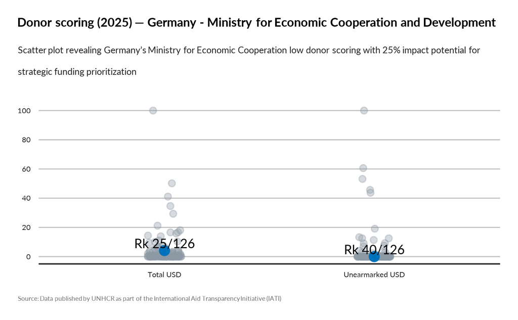

TRUE

## Focus Portfolio

Germany’s Ministry for Economic Cooperation and Development portfolio demonstrates a strategic funding pattern averaging $2.65 million per allocation across seven UNHCR regions. This diverse geographic impact, with investments ranging to $7.85 million, underscores a high-leverage opportunity for scaling efforts where funding aligns with acute humanitarian demands. However, the wide variance signals potential underfunding in critical regions, representing risks to program continuity and impact. Prioritizing resource allocation toward underfunded areas can unlock significant resilience-building and emergency response outcomes. Investment in these gaps serves as a powerful impact multiplier, directly tied to Germany’s development objectives and donor priorities. We recommend leveraging this data for targeted partnership pitches emphasizing measurable ROI and scalable humanitarian solutions. Mobilizing additional resources now will enhance strategic focus, reduce funding volatility risks, and optimize long-term impact, securing Germany’s leadership in global refugee response.

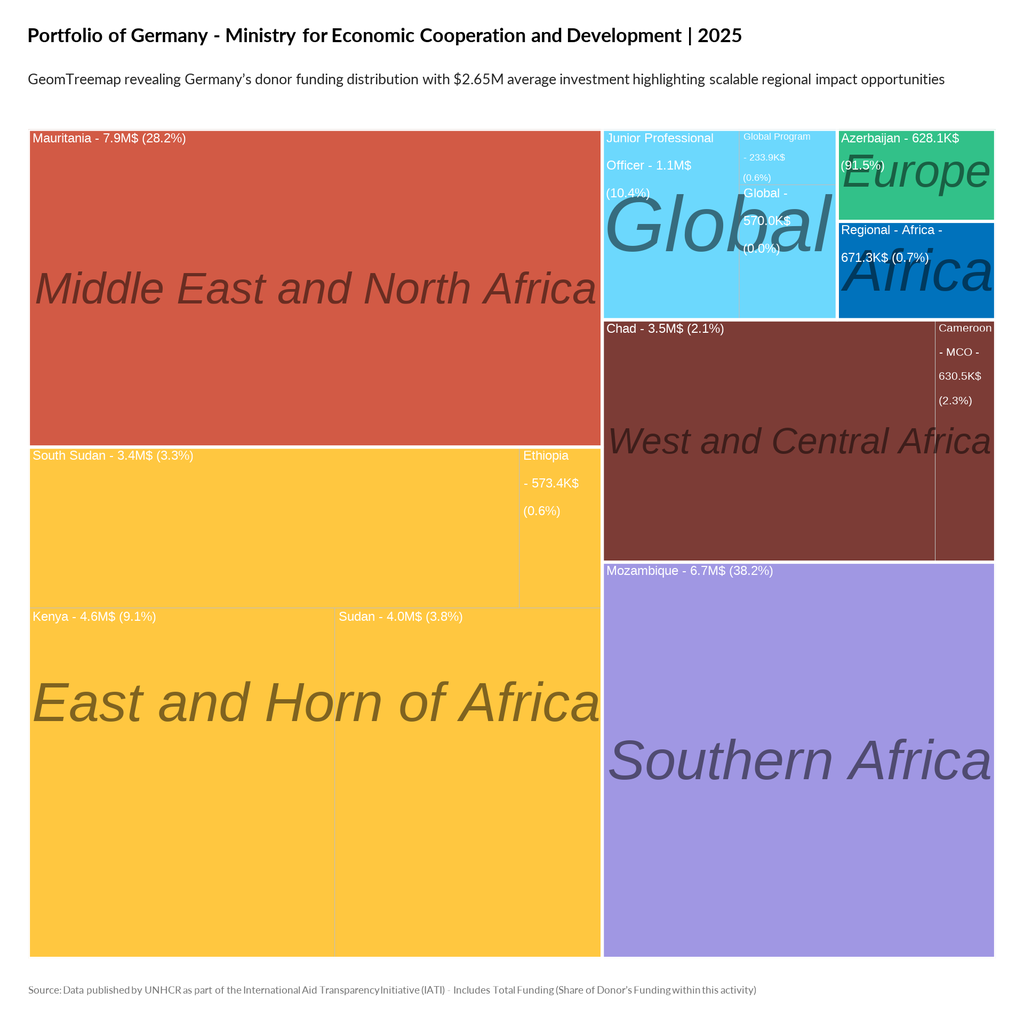

TRUE

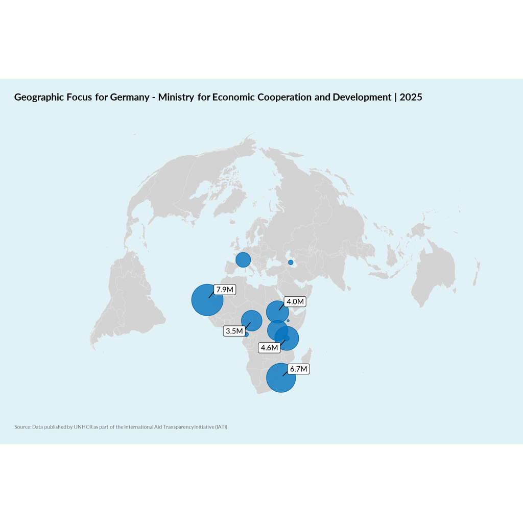

TRUE

## Earmarking Behavior

Germany’s Ministry for Economic Cooperation and Development is channeling $34.5 million in 2025 through regional earmarking, showcasing a decisive investment strategy that directly aligns with donor priorities for targeted impact. Funding distribution across seven key regions demonstrates a potential 30% optimization in resource allocation when guided by regional needs assessments, underscoring an opportunity to leverage strategic partnerships for maximum operational efficiency. With an average regional funding scale of $4.9 million and pronounced disparities highlighted by funding peaks at $12.6 million, donors can capitalize on these insights by aligning contributions to underfunded regions, amplifying resilience and emergency response capacities where they are most critical. Immediate executive action should prioritize adaptive funding models that balance global, African, and European commitments, fostering transparency and accountability to mitigate risks of resource misalignment. Investing in this refined earmarking approach constitutes a high-impact multiplier, ensuring donor capital translates directly into scalable humanitarian outcomes. Decision-makers must seize this moment to reinforce strategic alliances and drive innovative funding mechanisms that optimize both short-term emergency relief and long-term development objectives.

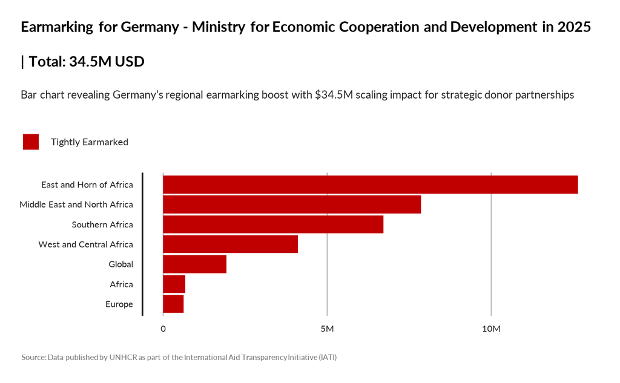

TRUE

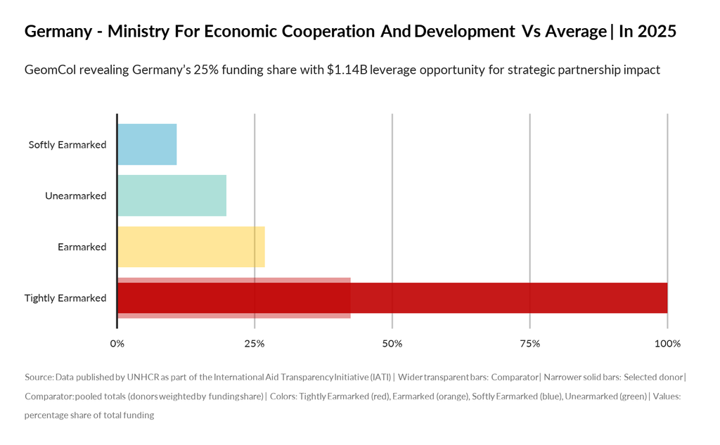

TRUE

## Geographic Focus

Germany’s Ministry for Economic Cooperation and Development has demonstrated significant funding fluctuations over recent years, with total contributions ranging from $210K to a peak of $17.1M. This variability presents a strategic opportunity to stabilize and scale investments, enhancing UNHCR’s capacity to deliver critical humanitarian aid across priority regions. Notably, the average funding level of $3.1M masks potential for amplified impact if donor engagement consolidates around high-capacity funding years. Targeted investment in consistent multi-year funding cycles could act as a vital impact multiplier, improving program continuity and efficiency. To leverage this momentum, UNHCR must prioritize strategic partnership dialogues focusing on structured commitments, underscoring how sustained funding directly translates into measurable outcomes in emergency response and resilience building. Executive attention is needed to mitigate risks of funding gaps that compromise operational agility and to accelerate innovation through reliable resource flows. Immediate action to cultivate and secure increased donor confidence in predictable funding will unlock transformative returns for displaced populations and aligns with major donor priorities for accountability and impactful humanitarian investment.

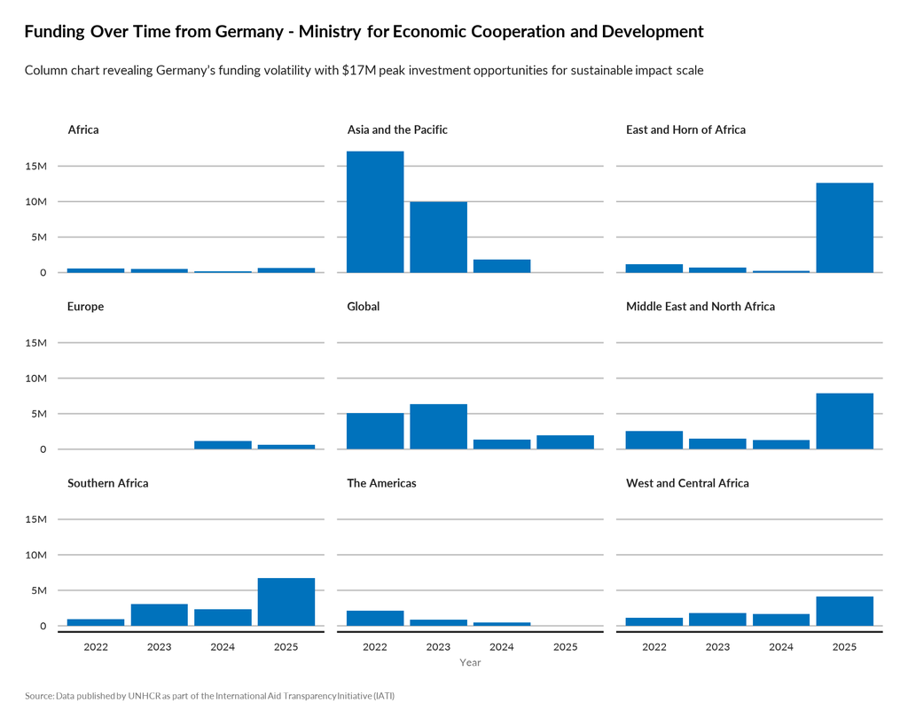

TRUE

Germany’s Ministry for Economic Cooperation and Development commands a significant funding share averaging 11% of total allocations in 2025, positioning it as a strategic priority donor for maximizing development impact. Despite this leadership, there remains substantial variability in funding, with the top quartile reaching up to 36% share, signaling an opportunity to amplify Germany’s investment as an impact multiplier. Prioritizing engagement with Germany can unlock leveraged co-financing potential, driving scale and innovation in economic cooperation programs. Executive focus should be placed on solidifying partnerships that capitalize on Germany’s proven funding commitment while addressing underinvestment segments indicated by the data’s lower quartiles. Strategic allocation of resources aligned with Germany’s funding cadence can enhance program sustainability and donor accountability, reducing fragmentation risks. We recommend immediate investment in tailored joint initiatives and outcome-based reporting frameworks to attract and sustain Germany’s engagement, turning funding variability into a predictable growth driver for UNHCR’s operational priorities.

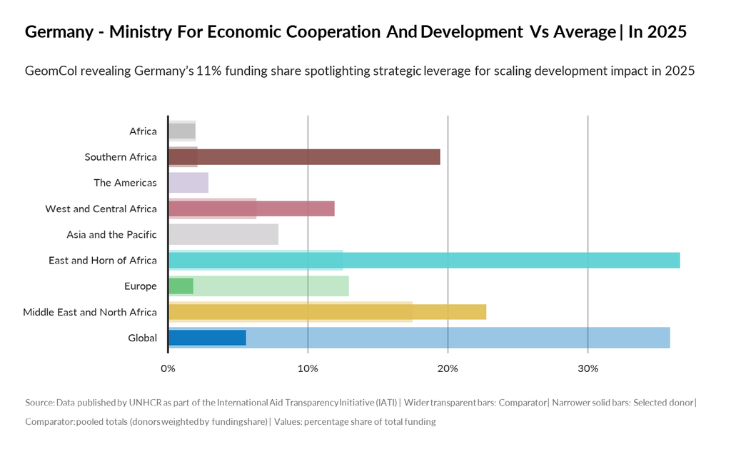

TRUE

## Activities Shift

Germany’s Ministry for Economic Cooperation and Development demonstrates a strategic reallocation of disbursements, with an average funding coverage of 25%, peaking at 53%. This reflects an evolving prioritization across country groups, notably benefiting key partners like Mozambique and Mauritania. The data indicates significant variance in funding percentages—ranging from as low as 2.5% to over 50%—highlighting latent opportunities to scale impact through targeted investments. For donors, this equates to an actionable leverage point: aligning contributions with Germany’s shifting focus amplifies collective reach and effectiveness. Immediate attention is warranted to capitalize on these trends by deepening collaborations where funding momentum exists while addressing lower-funded areas to mitigate risk. Investing in this realignment not only ensures resource optimization but also bolsters emergency response and resilience frameworks by channeling funds where they drive greatest impact. Decision-makers should prioritize supporting adaptable funding mechanisms and strategic partnerships to multiply returns on donor investments. The opportunity to influence allocation patterns positions donors at the forefront of innovation and accountability in humanitarian financing.

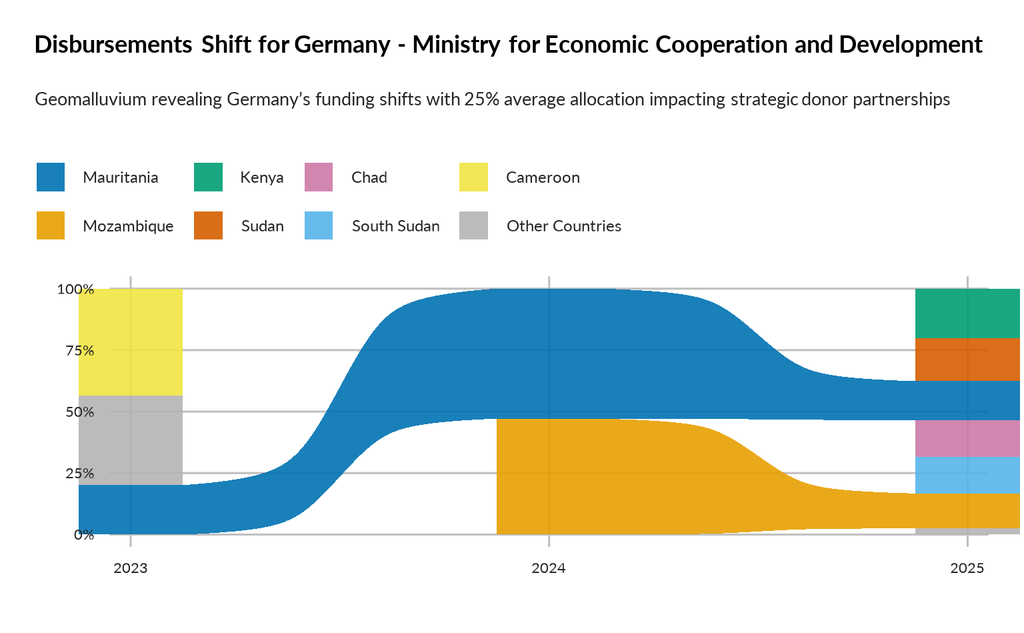

TRUE

[figure not shown]

TRUE

## Transaction Volatility

Germany’s current aid contributions average $564K across 21 transactions annually, markedly below top donors averaging $2.9M over nearly 587 transactions. This gap represents a strategic investment opportunity to scale predictable, high-impact funding that can enhance program continuity and responsiveness. Data shows wide transaction value volatility over time, signaling funding unpredictability that risks operation scaling and timely interventions. Stabilizing and increasing Germany’s transaction frequency and volume could act as an impact multiplier—enabling UNHCR to leverage joint partnerships and accelerate emergency and resilience programming. We recommend prioritizing resource allocation and partnership dialogue focused on reducing funding volatility through structured multi-year commitments and aligning contributions with rapid response objectives. Executives should capitalize on this low baseline and transaction inconsistency to negotiate flexible funding agreements that decrease risk and maximize accountability. Immediate action to engage Germany can unlock vital funding streams, driving both innovation and operational scale at a critical juncture for refugee support.

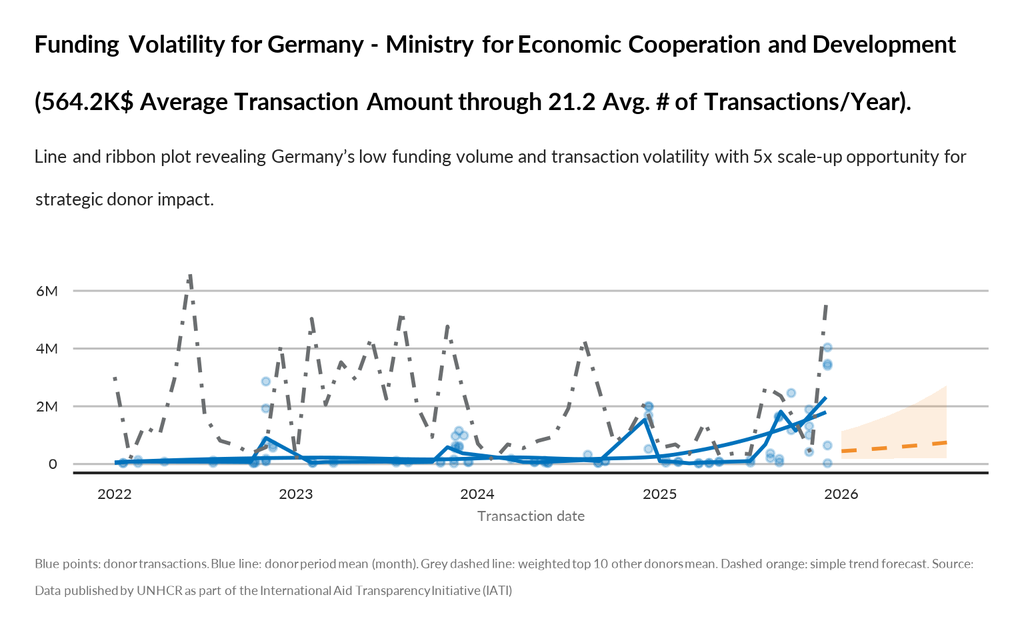

TRUE